# REGRESSION MODEL EVALUATION

JOSÉ LUIS

2024-11-14

# CÓDIGO

EN ESTE PROYECTO VAMOS A VISUALIZAR DE MANERA EFICIENTE LOS DATOS Y VER COMO HACER UN MODELO DE REGRESIÓN Y EVALUAREMOS EL MODELO A TRAVÉS DE SUS RESIDUOS.

## LIBRERIAS

```r
library(caret)
library(dplyr)
library(ggplot2)
library(ggthemes)
library(kableExtra)
library(psych)
library(skimr)
library(tidymodels)
library(tidyverse)
library(GGally)
library(lmtest)
library(corrplot)
```

## DATASET Y VARIABLES

EL DATASET QUE VAMOS A ESCOGER PARA HACER ESTE PEQUEÑO PROYECTO, ES EL DE mtcars, QUE VIENE DE BASE EN R.

```r
# Primero observamos un poco el dataset
data = mtcars

head(data) %>% kable(format = "html") %>%
  kable_styling(bootstrap_options = c("striped", "hover", "condensed"),
                full_width = FALSE, position = "center", font_size = 12) %>%
  row_spec(0, background = "#287289", color = "white")
```

|  | mpg | cyl | disp | hp | drat | wt | qsec | vs | am | gear | carb |
| --- | --- | --- | --- | --- | --- | --- | --- | --- | --- | --- | --- |
| Mazda RX4 | 21.0 | 6 | 160 | 110 | 3.90 | 2.620 | 16.46 | 0 | 1 | 4 | 4 |
| Mazda RX4 Wag | 21.0 | 6 | 160 | 110 | 3.90 | 2.875 | 17.02 | 0 | 1 | 4 | 4 |
| Datsun 710 | 22.8 | 4 | 108 | 93 | 3.85 | 2.320 | 18.61 | 1 | 1 | 4 | 1 |
| Hornet 4 Drive | 21.4 | 6 | 258 | 110 | 3.08 | 3.215 | 19.44 | 1 | 0 | 3 | 1 |
| Hornet Sportabout | 18.7 | 8 | 360 | 175 | 3.15 | 3.440 | 17.02 | 0 | 0 | 3 | 2 |
| Valiant | 18.1 | 6 | 225 | 105 | 2.76 | 3.460 | 20.22 | 1 | 0 | 3 | 1 |

```r
str(data)
```

```
'data.frame':   32 obs. of  11 variables:
 $ mpg : num  21 21 22.8 21.4 18.7 18.1 14.3 24.4 22.8 19.2 ...
 $ cyl : num  6 6 4 6 8 6 8 4 4 6 ...
 $ disp: num  160 160 108 258 360 ...
 $ hp  : num  110 110 93 110 175 105 245 62 95 123 ...
 $ drat: num  3.9 3.9 3.85 3.08 3.15 2.76 3.21 3.69 3.92 3.92 ...
 $ wt  : num  2.62 2.88 2.32 3.21 3.44 ...
 $ qsec: num  16.5 17 18.6 19.4 17 ...
 $ vs  : num  0 0 1 1 0 1 0 1 1 1 ...
 $ am  : num  1 1 1 0 0 0 0 0 0 0 ...
 $ gear: num  4 4 4 3 3 3 3 4 4 4 ...
 $ carb: num  4 4 1 1 2 1 4 2 2 4 ...
```

VARIABLES:

**mpg:** Miles per Gallon (Millas por galón)

**Descripción:** Eficiencia de combustible del auto, es decir, el número de millas que el vehículo puede recorrer por cada galón de gasolina.

**Tipo:** Numérica

**cyl:** Cylinders (Cilindrada)

**Descripción:** Número de cilindros del motor del auto. Los autos con más cilindros tienden a tener más potencia, pero suelen ser menos eficientes en cuanto a consumo de combustible.

**Tipo:** Categórica (ordinal)

**disp:** Displacement (Desplazamiento del motor)

**Descripción:** Volumen total de los cilindros del motor, medido en pulgadas cúbicas. Un mayor desplazamiento generalmente indica un motor más grande y potente.

**Tipo:** Numérica

**hp:** Horsepower (Caballos de fuerza)

**Descripción:** Potencia del motor medida en caballos de fuerza. Una mayor cantidad de caballos de fuerza usualmente implica mayor rendimiento y velocidad.

**Tipo:** Numérica

**drat:** Rear Axle Ratio (Relación del eje trasero)

**Descripción:** Relación entre las revoluciones del eje de transmisión trasero y las del motor. Influye en la aceleración y el consumo de combustible.

**Tipo:** Numérica

**wt:** Weight (Peso)

**Descripción:** Peso del automóvil medido en miles de libras. El peso afecta la eficiencia del combustible y el rendimiento del vehículo.

**Tipo:** Numérica

**qsec:** 1/4 Mile Time (Tiempo en el cuarto de milla)

**Descripción:** Tiempo en segundos que tarda el auto en recorrer un cuarto de milla (aproximadamente 402 metros). Es una medida de la aceleración del vehículo.

**Tipo:** Numérica

**vs:** Engine Shape (Tipo de motor)

**Descripción:** Tipo de motor: 0 para motor en línea y 1 para motor en V. Esta variable es categórica.

**Tipo:** Categórica (binaria)

am: Transmission (Transmisión)

**Descripción:** Tipo de transmisión del auto: 0 para transmisión automática y 1 para transmisión manual.

**Tipo:** Categórica (binaria)

**gear:** Gears (Número de marchas)

**Descripción:** Número de marchas en la transmisión del vehículo.

**Tipo:** Categórica (ordinal)

**carb:** Carburetors (Carburadores)

**Descripción:** Número de carburadores del automóvil, un componente que mezcla el aire con el combustible para el motor.

**Tipo:** Numérica

LAS VARIABLES CATEGORICAS EN ESTE DATASET YA ESTÁN CODIFICADAS, POR LO QUE NO HACE FALTA NINGUN PREPROCESAMIENTO DE ESTE ESTILO.

## ANÁLISIS EXPLORATORIO

VAMOS A HACER UN PEQUEÑO ANÁLISIS EXPLOTATORIO CON SUMMARY() Y SKIM()

```r
summary(data)
```

```
      mpg             cyl             disp             hp
 Min.   :10.40   Min.   :4.000   Min.   : 71.1   Min.   : 52.0
 1st Qu.:15.43   1st Qu.:4.000   1st Qu.:120.8   1st Qu.: 96.5
 Median :19.20   Median :6.000   Median :196.3   Median :123.0
 Mean   :20.09   Mean   :6.188   Mean   :230.7   Mean   :146.7
 3rd Qu.:22.80   3rd Qu.:8.000   3rd Qu.:326.0   3rd Qu.:180.0
 Max.   :33.90   Max.   :8.000   Max.   :472.0   Max.   :335.0
      drat             wt             qsec             vs
 Min.   :2.760   Min.   :1.513   Min.   :14.50   Min.   :0.0000
 1st Qu.:3.080   1st Qu.:2.581   1st Qu.:16.89   1st Qu.:0.0000
 Median :3.695   Median :3.325   Median :17.71   Median :0.0000
 Mean   :3.597   Mean   :3.217   Mean   :17.85   Mean   :0.4375
 3rd Qu.:3.920   3rd Qu.:3.610   3rd Qu.:18.90   3rd Qu.:1.0000
 Max.   :4.930   Max.   :5.424   Max.   :22.90   Max.   :1.0000
       am              gear            carb
 Min.   :0.0000   Min.   :3.000   Min.   :1.000
 1st Qu.:0.0000   1st Qu.:3.000   1st Qu.:2.000
 Median :0.0000   Median :4.000   Median :2.000
 Mean   :0.4062   Mean   :3.688   Mean   :2.812
 3rd Qu.:1.0000   3rd Qu.:4.000   3rd Qu.:4.000
 Max.   :1.0000   Max.   :5.000   Max.   :8.000
```

```r
skim(data)
```

Data summary

| Name | data |
| --- | --- |
| Number of rows | 32 |
| Number of columns | 11 |
| _______________________ |  |
| Column type frequency: |  |
| numeric | 11 |
| ________________________ |  |
| Group variables | None |

**Variable type: numeric**

| skim_variable | n_missing | complete_rate | mean | sd | p0 | p25 | p50 | p75 | p100 | hist |
| --- | --- | --- | --- | --- | --- | --- | --- | --- | --- | --- |
| mpg | 0 | 1 | 20.09 | 6.03 | 10.40 | 15.43 | 19.20 | 22.80 | 33.90 | ▃▇▅▁▂ |
| cyl | 0 | 1 | 6.19 | 1.79 | 4.00 | 4.00 | 6.00 | 8.00 | 8.00 | ▆▁▃▁▇ |
| disp | 0 | 1 | 230.72 | 123.94 | 71.10 | 120.83 | 196.30 | 326.00 | 472.00 | ▇▃▃▃▂ |
| hp | 0 | 1 | 146.69 | 68.56 | 52.00 | 96.50 | 123.00 | 180.00 | 335.00 | ▇▇▆▃▁ |
| drat | 0 | 1 | 3.60 | 0.53 | 2.76 | 3.08 | 3.70 | 3.92 | 4.93 | ▇▃▇▅▁ |
| wt | 0 | 1 | 3.22 | 0.98 | 1.51 | 2.58 | 3.33 | 3.61 | 5.42 | ▃▃▇▁▂ |
| qsec | 0 | 1 | 17.85 | 1.79 | 14.50 | 16.89 | 17.71 | 18.90 | 22.90 | ▃▇▇▂▁ |
| vs | 0 | 1 | 0.44 | 0.50 | 0.00 | 0.00 | 0.00 | 1.00 | 1.00 | ▇▁▁▁▆ |
| am | 0 | 1 | 0.41 | 0.50 | 0.00 | 0.00 | 0.00 | 1.00 | 1.00 | ▇▁▁▁▆ |
| gear | 0 | 1 | 3.69 | 0.74 | 3.00 | 3.00 | 4.00 | 4.00 | 5.00 | ▇▁▆▁▂ |
| carb | 0 | 1 | 2.81 | 1.62 | 1.00 | 2.00 | 2.00 | 4.00 | 8.00 | ▇▂▅▁▁ |

DEJO COMO PROPUESTA INTERPRETAR ESTOS RESULTADOS, YA QUE EL ANÁLISIS PRINCIPAL DE ESTE PROYECTO ES EL MODELO DE REGRESIÓN. SUMMARY() Y SKIM() LOS HE USADO PARA DAR OPCIONES A LA HORA DE HACER UN ANÁLISIS EXPLORATORIO COMPLETO Y SENCILLO EN POCO TIEMPO.

## VISUALIZACIÓN DE DATOS

PARA LA VISUALIZACIÓN DE LOS DATOS, UTILIZAREMOS VARIOS GRÁFICOS CLÁSICOS Y OTROS UN POCO MÁS COMPLEJOS QUE NOS DARÁN MÁS INFORMACIÓN DE NUESTROS DATOS

### BOXPLOT

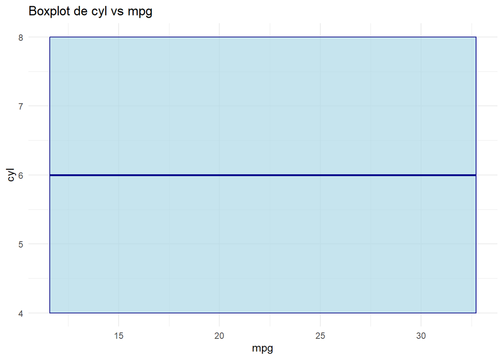

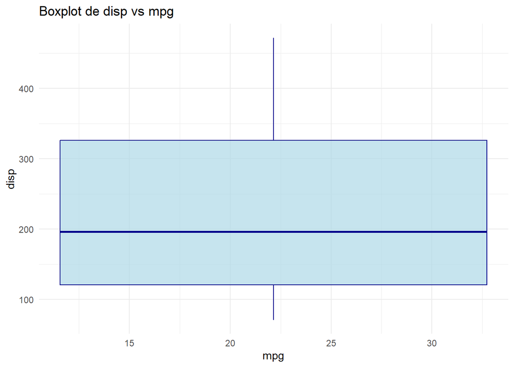

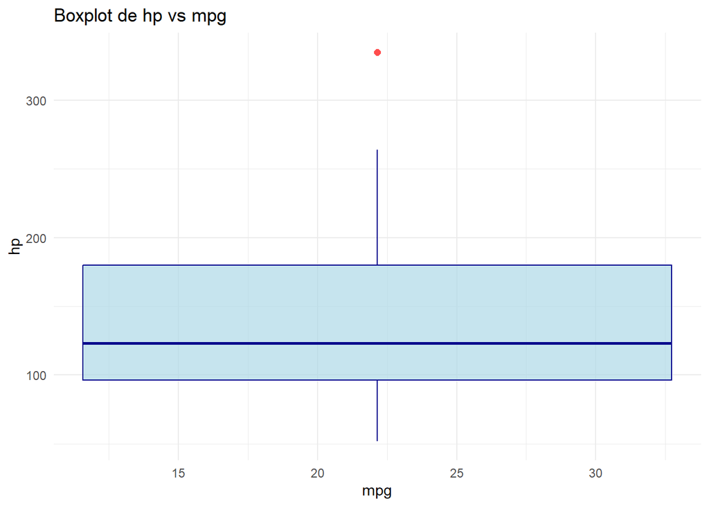

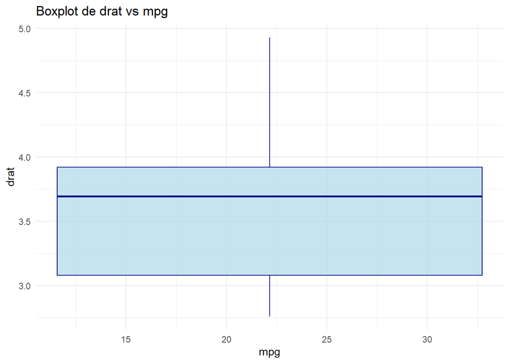

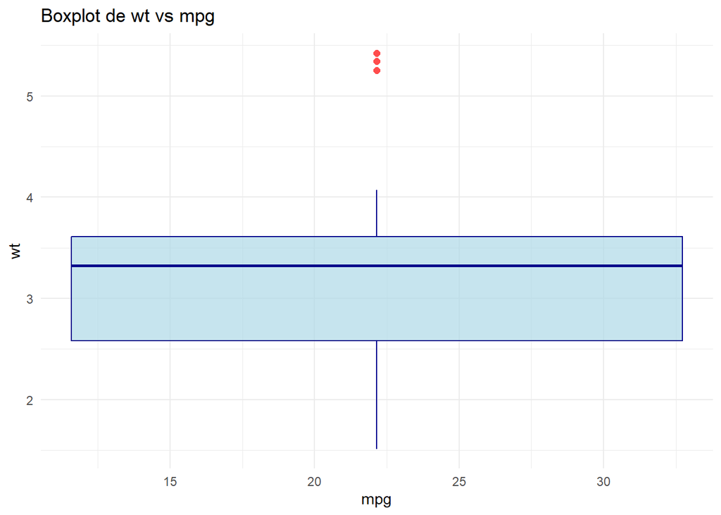

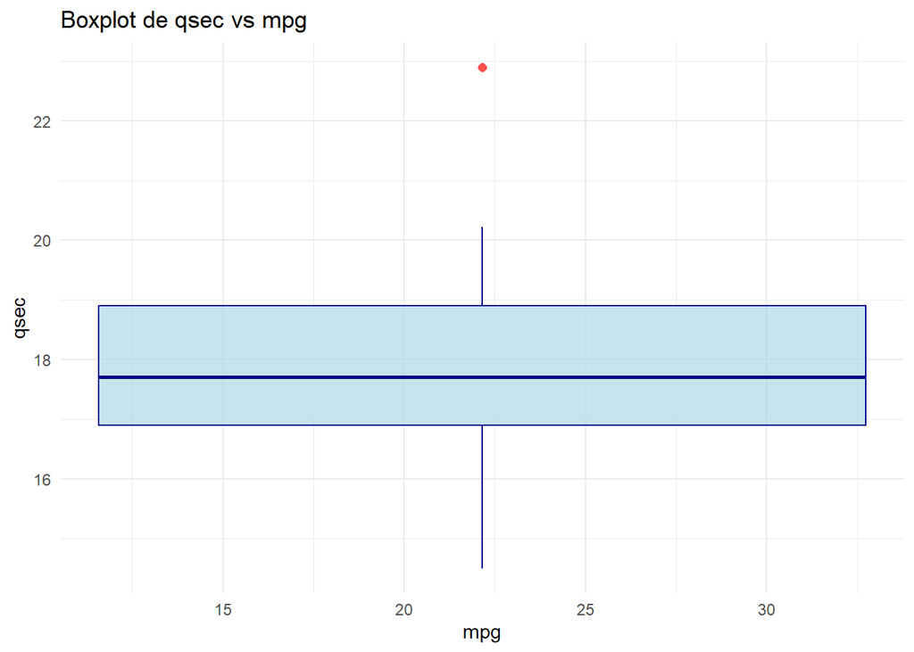

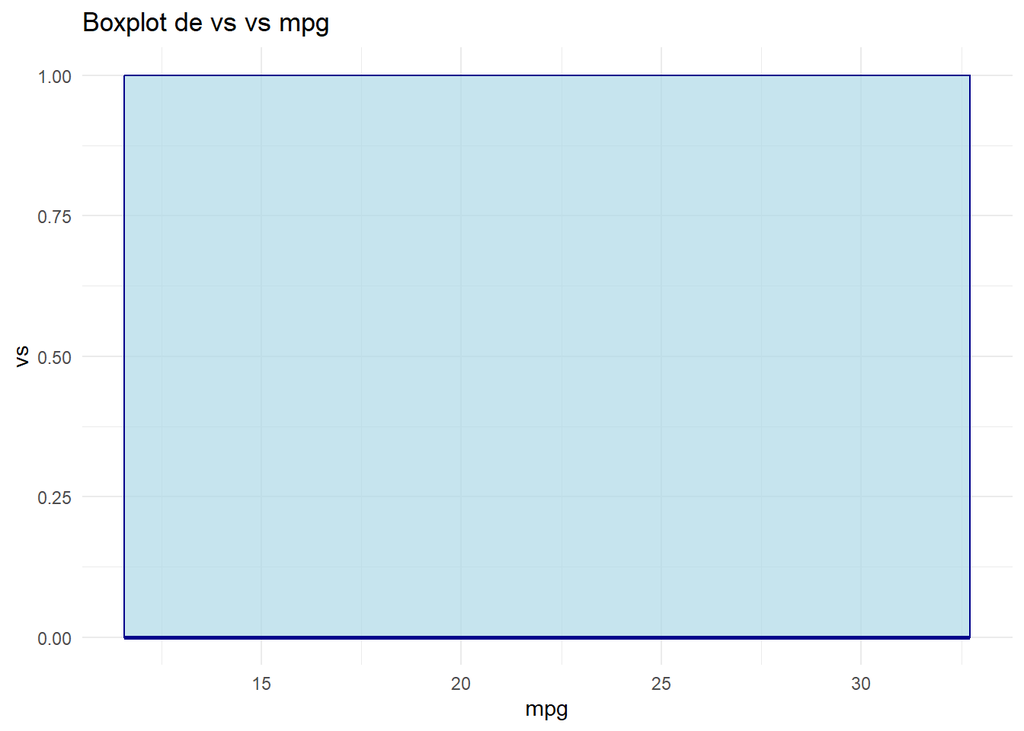

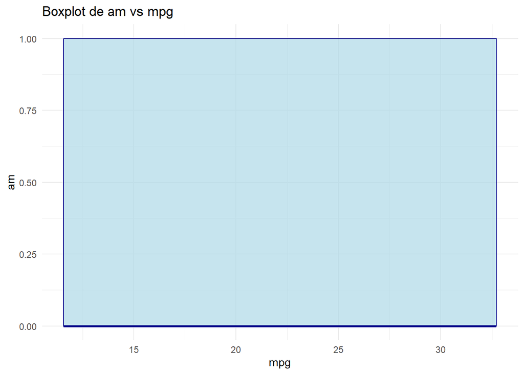

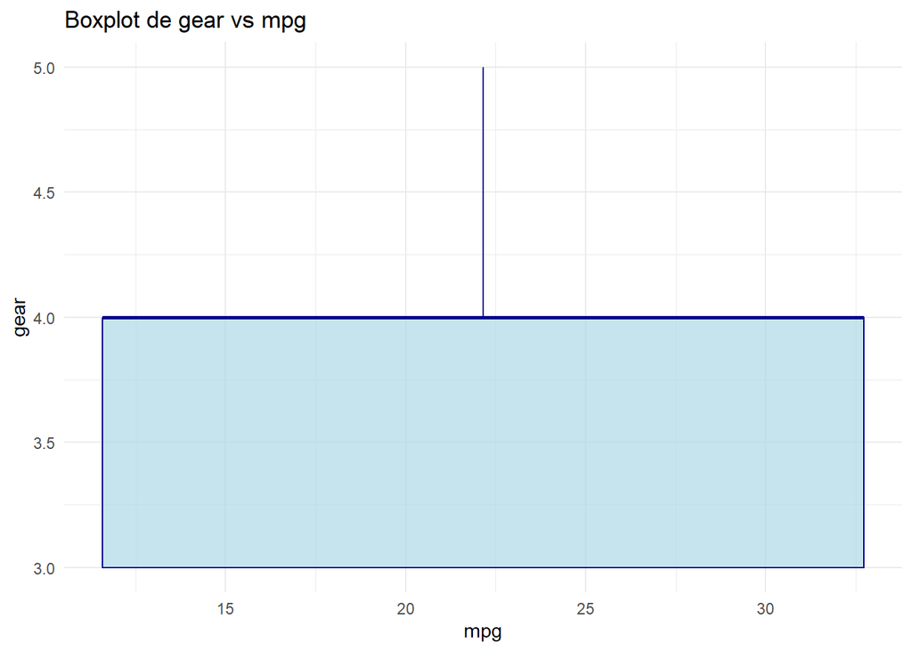

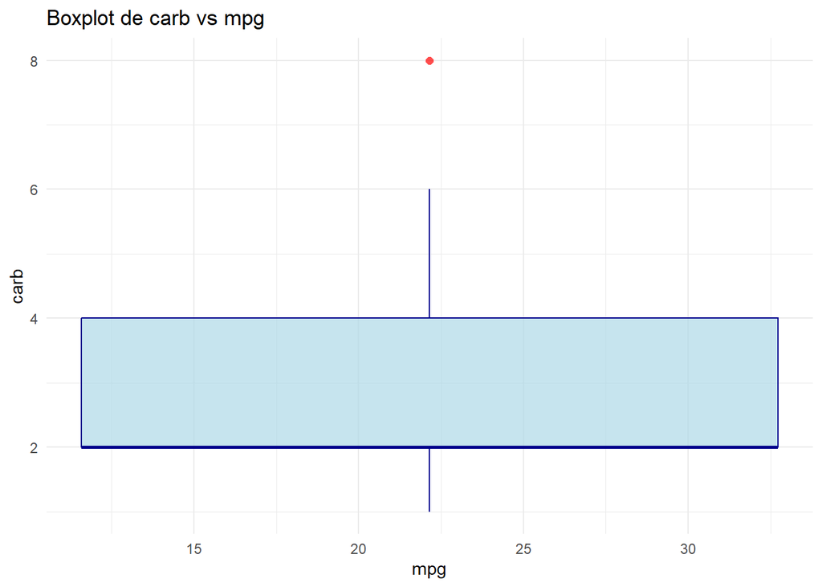

```r
# Cogemos las variables numericas
variables_numericas = data %>%
  select(where(is.numeric))

# Hacemos un boxplot sencillo
for (var in colnames(variables_numericas)) {
  if (var != "mpg") {
    g = ggplot(data, aes(x = mpg, y = variables_numericas[[var]], col = mpg)) +
      geom_boxplot(fill = "lightblue", color = "darkblue", outlier.shape = 16, outlier.size = 2, outlier.colour = "red", alpha = 0.7) +
      theme_minimal() +
      labs(x = "mpg", y = var) +
      ggtitle(paste("Boxplot de", var, "vs mpg"))

  print(g)
  }
}
```


### VIOLIN PLOT

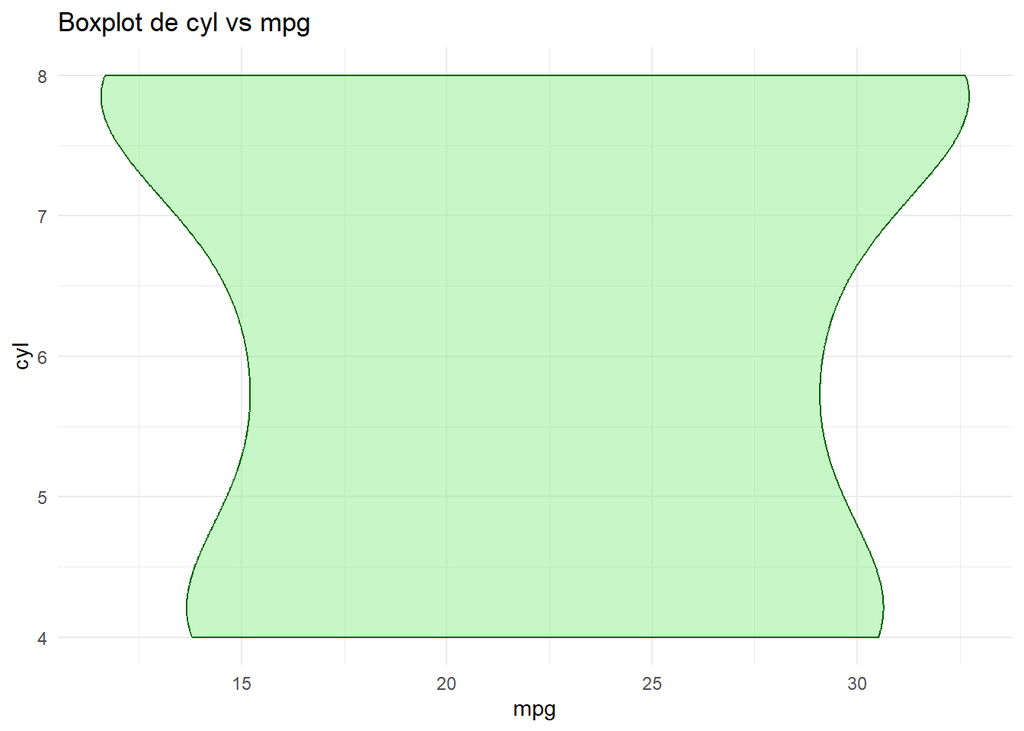

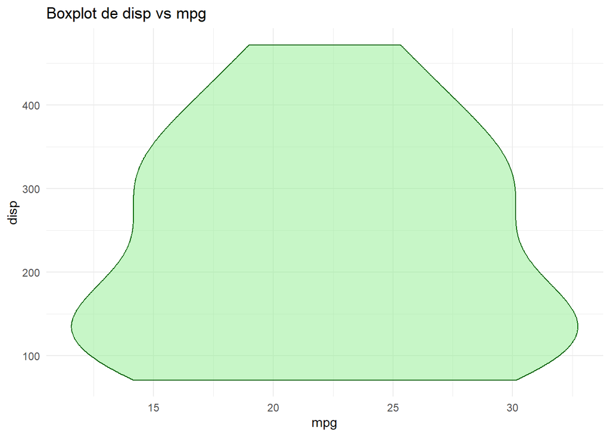

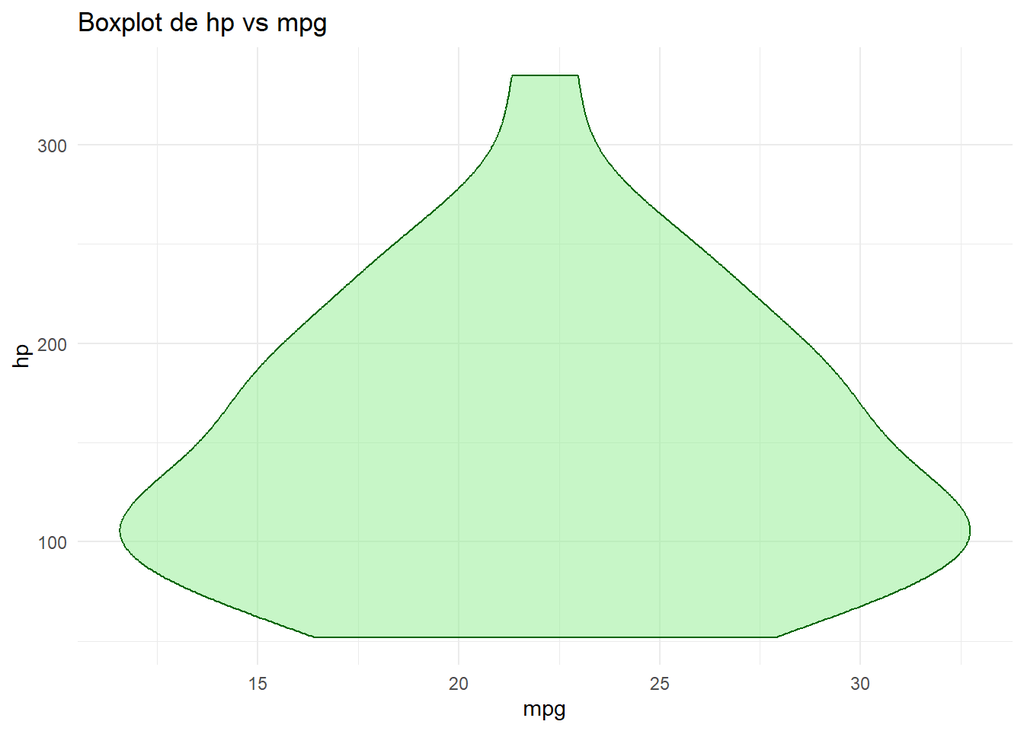

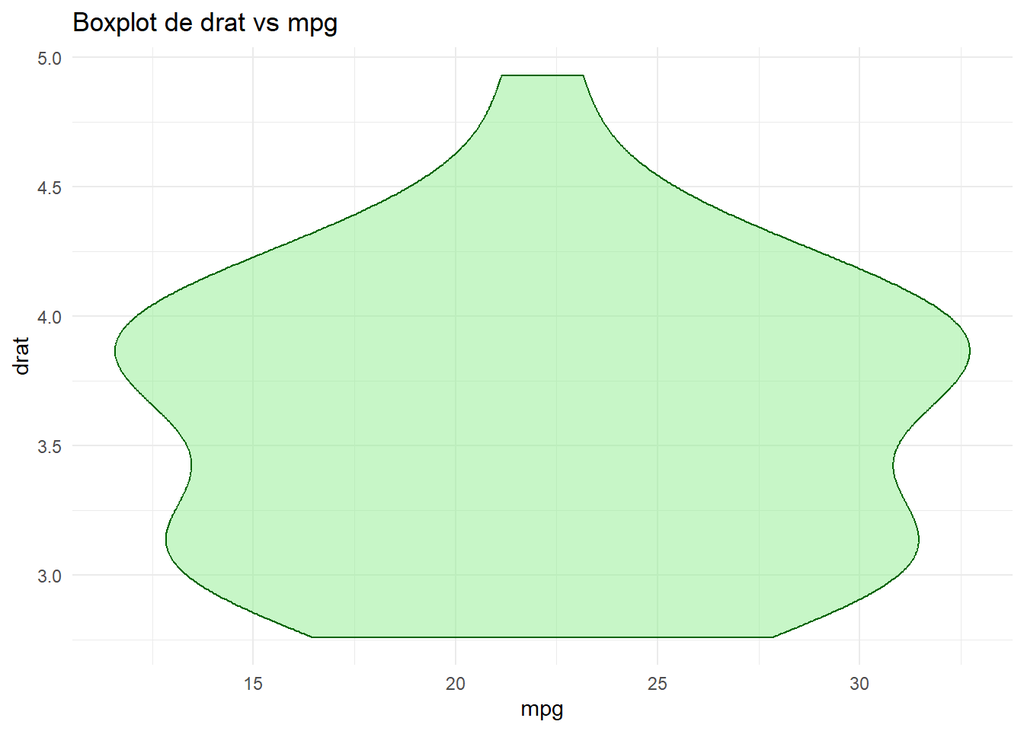

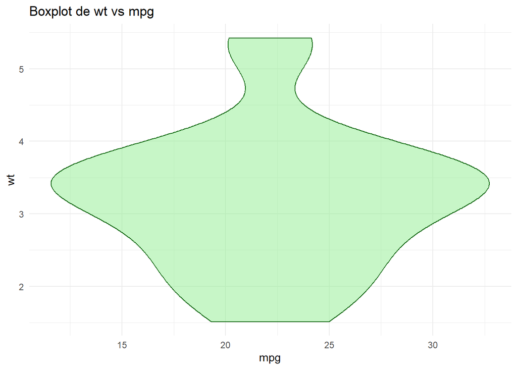

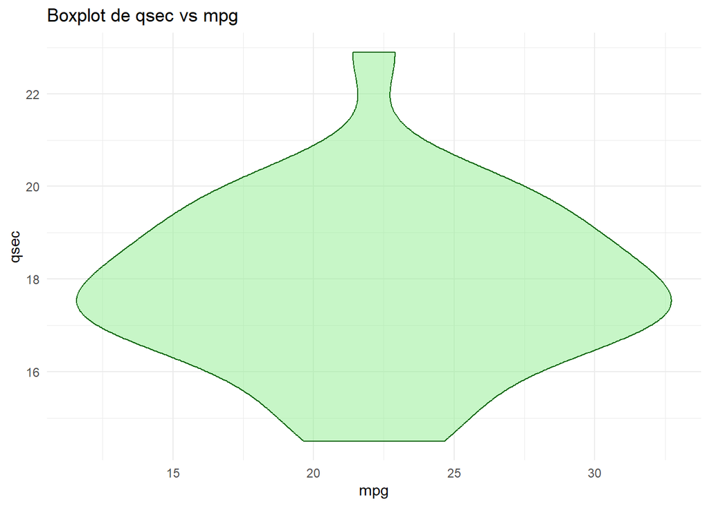

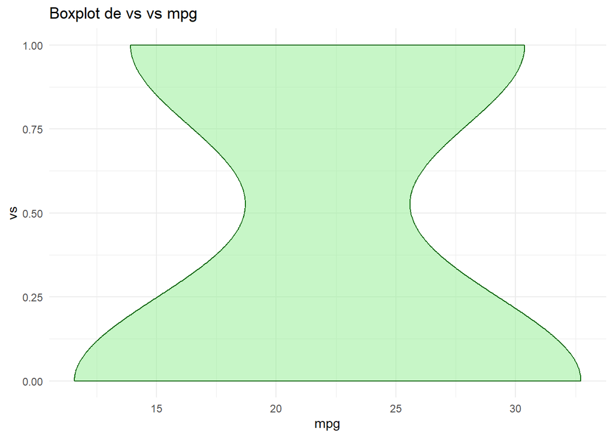

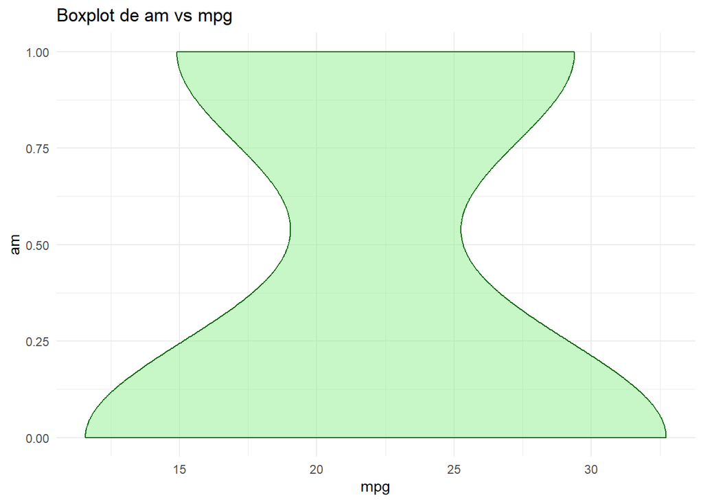

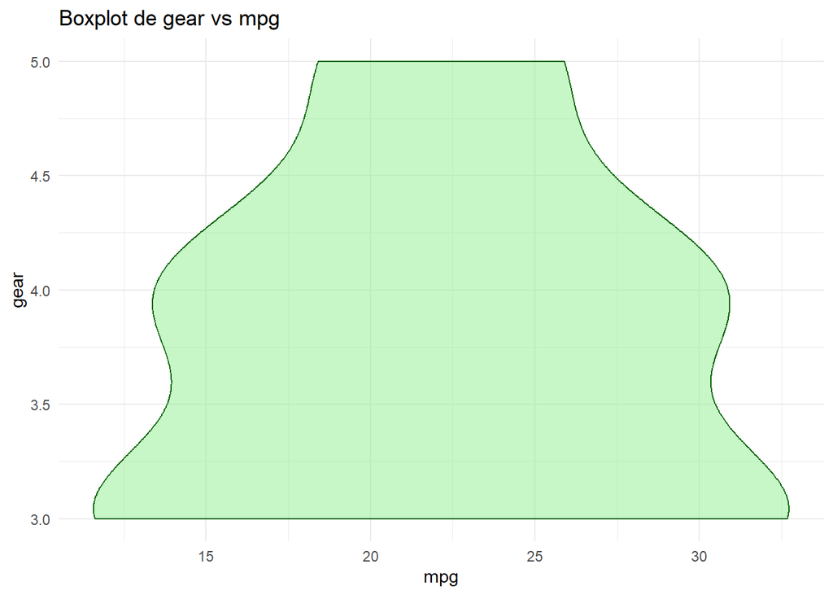

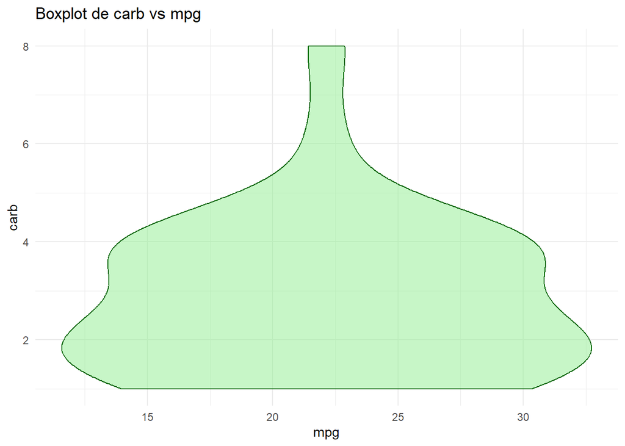

```r
# Cogemos las variables numericas
variables_numericas = data %>%
  select(where(is.numeric))

# Hacemos un Violin plot sencillo
for (var in colnames(variables_numericas)) {
  if (var != "mpg") {
    g = ggplot(data, aes(x = mpg, y = variables_numericas[[var]], col = mpg)) +
      geom_violin(fill = "lightgreen", color = "darkgreen", alpha = 0.5, trim = TRUE, adjust = 1.2) +
      theme_minimal() +
      labs(x = "mpg", y = var) +
      ggtitle(paste("Boxplot de", var, "vs mpg"))

  print(g)
  }
}
```

LOS VIOLIN PLOT SIRVEN MÁS PARA VER DONDE HAY MÁS DENSIDAD DE LOS DATOS. CUANTO MÁS ANCHO, MÁS CONCENTRACIÓN DE DATOS HAY

### GRÁFICO DE DISPERSION

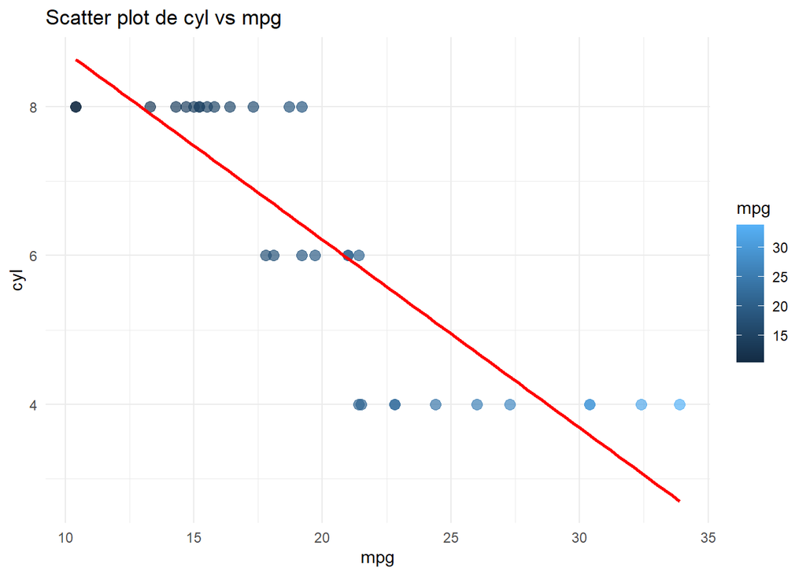

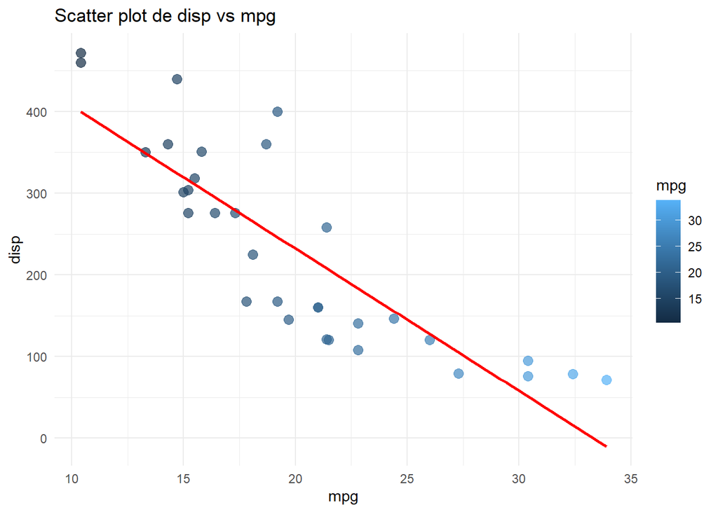

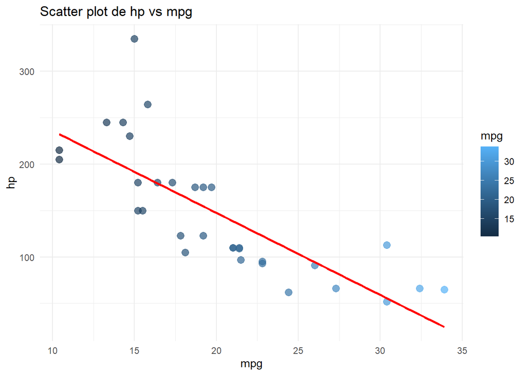

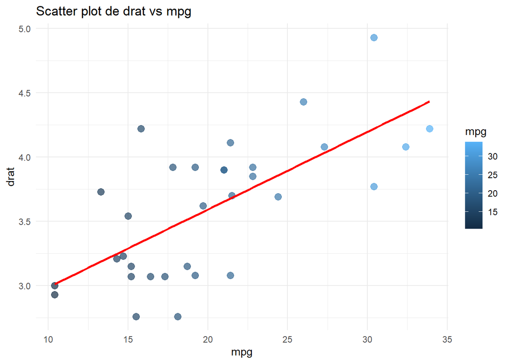

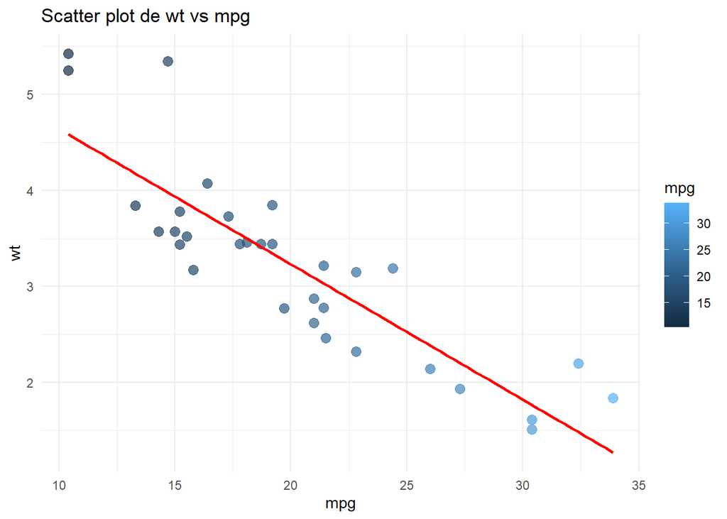

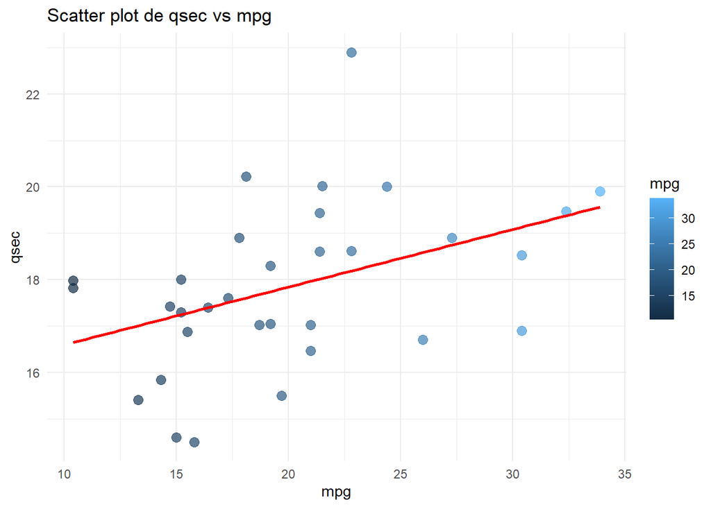

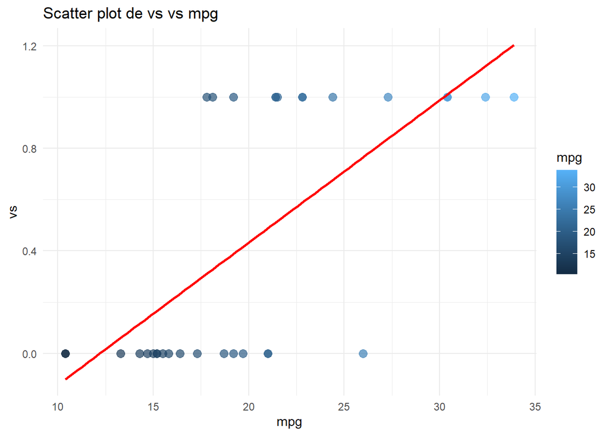

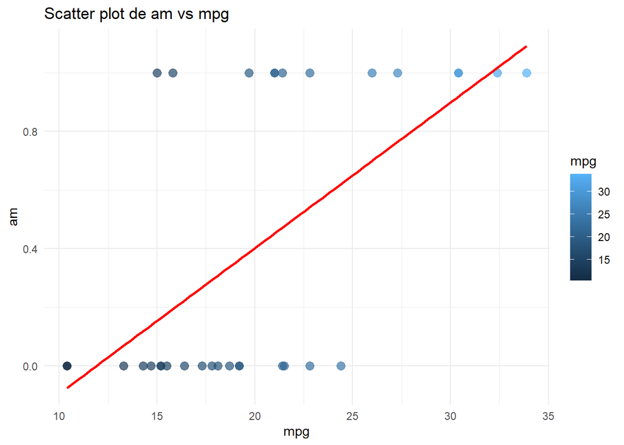

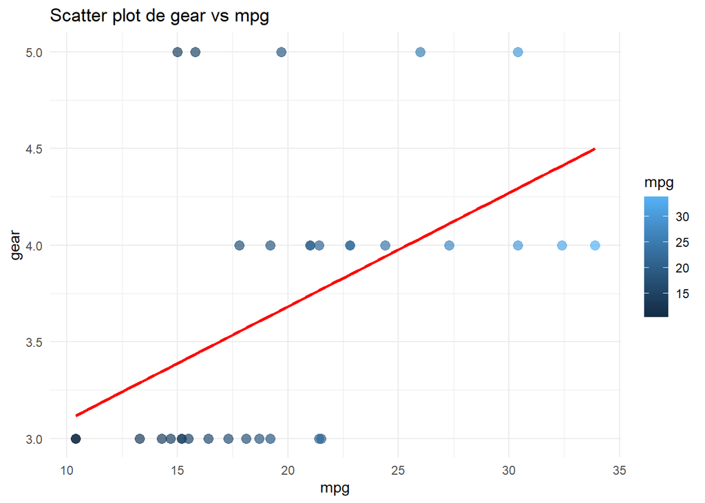

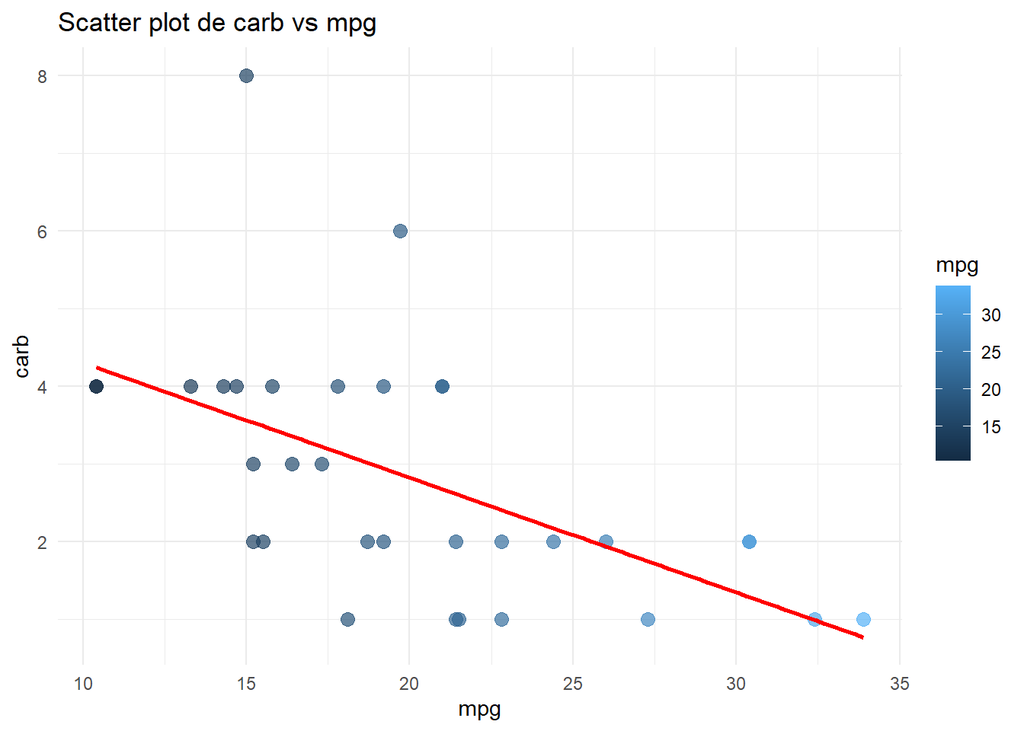

```r
# Hacemos un gráfico de dispersion con línea de regresión
for (var in colnames(variables_numericas)) {
  if (var != "mpg") {
    g = ggplot(data, aes(x = mpg, y = variables_numericas[[var]], col = mpg)) +
      geom_point(size = 3, alpha = 0.7) +  # Puntos del scatter plot
      geom_smooth(method = "lm", se = FALSE, color = "red") +  # Línea de regresión lineal (sin intervalo de confianza)
      theme_minimal() +
      labs(x = "mpg", y = var) +  # Etiquetas de los ejes
      ggtitle(paste("Scatter plot de", var, "vs mpg"))  # Título del gráfico

    print(g)
  }
}
```

EL GRÁFICO DE DISPERSIÓN ES EL MEJOR GRÁFICO SI LO QUE BUSCAMOS ES VER COMO ES LA RELACIÓN ENTRE VARIABLES (LINEAL, LOGISTICA, HIPERBÓLICA, ETC). EVIDENTEMENTE, PARA LAS VARIABLES CATEGORICAS LA RELACIÓN NO VA A SER LINEAL, COMO SE MUESTRA EN LOS GRÁFICOS PARA “cyl”, “vs”, “am”, “gear” o “carb” PORQUE SON NIVELES. EN LAS VARIABLES NUMÉRICAS, POR OTRO LADO, SI QUE SE PUEDE VER CIERTA TENDENCIA LINEAL (YA SEA POSITIVA O NEGATIVA).

VAMOS A HACER UNA MATRIZ DE CORRELACIÓN PARA OBSERVAR ALGO MEJOR LA RELACIÓN ENTRE LAS VARIABLES PREDICTORAS ENTRE SI Y CON LA TARGET.

```r
# Calcular la matriz de correlación
cor_matrix = cor(variables_numericas)

# Mostrar la matriz de correlación
print(cor_matrix)
```

```
            mpg        cyl       disp         hp        drat         wt
mpg   1.0000000 -0.8521620 -0.8475514 -0.7761684  0.68117191 -0.8676594
cyl  -0.8521620  1.0000000  0.9020329  0.8324475 -0.69993811  0.7824958
disp -0.8475514  0.9020329  1.0000000  0.7909486 -0.71021393  0.8879799
hp   -0.7761684  0.8324475  0.7909486  1.0000000 -0.44875912  0.6587479
drat  0.6811719 -0.6999381 -0.7102139 -0.4487591  1.00000000 -0.7124406
wt   -0.8676594  0.7824958  0.8879799  0.6587479 -0.71244065  1.0000000
qsec  0.4186840 -0.5912421 -0.4336979 -0.7082234  0.09120476 -0.1747159
vs    0.6640389 -0.8108118 -0.7104159 -0.7230967  0.44027846 -0.5549157
am    0.5998324 -0.5226070 -0.5912270 -0.2432043  0.71271113 -0.6924953
gear  0.4802848 -0.4926866 -0.5555692 -0.1257043  0.69961013 -0.5832870
carb -0.5509251  0.5269883  0.3949769  0.7498125 -0.09078980  0.4276059
            qsec         vs          am       gear        carb
mpg   0.41868403  0.6640389  0.59983243  0.4802848 -0.55092507
cyl  -0.59124207 -0.8108118 -0.52260705 -0.4926866  0.52698829
disp -0.43369788 -0.7104159 -0.59122704 -0.5555692  0.39497686
hp   -0.70822339 -0.7230967 -0.24320426 -0.1257043  0.74981247
drat  0.09120476  0.4402785  0.71271113  0.6996101 -0.09078980
wt   -0.17471588 -0.5549157 -0.69249526 -0.5832870  0.42760594
qsec  1.00000000  0.7445354 -0.22986086 -0.2126822 -0.65624923
vs    0.74453544  1.0000000  0.16834512  0.2060233 -0.56960714
am   -0.22986086  0.1683451  1.00000000  0.7940588  0.05753435
gear -0.21268223  0.2060233  0.79405876  1.0000000  0.27407284
carb -0.65624923 -0.5696071  0.05753435  0.2740728  1.00000000
```

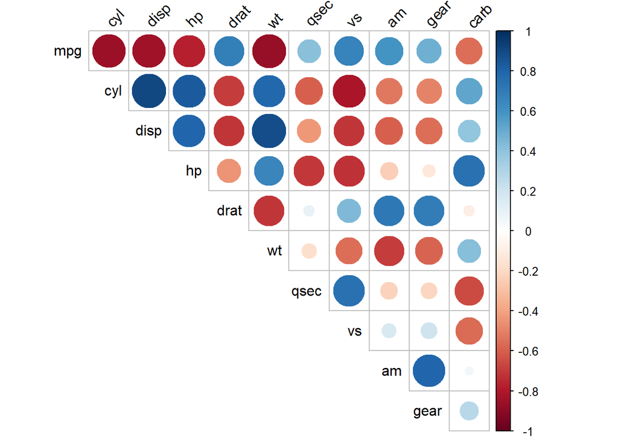

```r
# Visualizar la matriz de correlación con corrplot
corrplot(cor_matrix, method = "circle", type = "upper",
         tl.col = "black", tl.srt = 45, # Ajustar la orientación de los nombres de las variables
         diag = FALSE) # Opcional: eliminar la diagonal (ya que siempre es 1)
```

SE DEJA PARA LAS PERSONAS QUE VEAN ESTE PROYECTO QUE SAQUEN SUS PROPIAS RELACIONES ENTRE LAS VARIABLES.

## CONSTRUCCIÓN MODELO DE REGRESIÓN Y ELECCIÓN DE VARIABLES

ESTE DATASET ESTÁ MUY PREPARADO PARA QUE HAGAMOS UN MODELO LINEAL Y YA. PERO ESE NO ES NUESTRO OBJETIVO, YA QUE ESCRIBIR UN PAR DE LINEAS DE CÓDIGO LO PUEDE HACER TODO EL MUNDO. CUANDO NOSOTROS TENEMOS UN DATASET PROPIO, TODO EL ANÁLISIS PREVIO NOS SIRVE PARA VER QUE VARIABLES SON LAS QUE MÁS PODRÍAN CONTRIBUIR A LA VARIABLE TARGET “mpg” (EN ESTE CASO). A LA HORA DE CONSTRUIR NUESTRO MODELO, ENTONCES, ¿QUE VARIABLES ESCOGEMOS Y CUALES NO? BIEN, PODRIAMOS, PRIMERO, DE LA MATRIZ DE CORRELACIÓN ANTERIOR, ANALIZAR CUALES ESTÁN ALTAMENTE CORRELACIONADAS Y, SIMPLEMENTE, NO AÑADIRLAS A NUESTRO MODELO. CUANDO TENEMOS MUCHAS VARIABLES, PROBABLEMENTE ESTE MÉTODO NOS QUITE BASTANTE TRABAJO. SIN EMBARGO, ESTAMOS ANTE UN DATASET PEQUEÑO, POR LO QUE PODRIAMOS HACER LO QUE SE CONOCE COMO **SELECCIÓN HACIA DELANTE** O **FORWARD SELECTION** QUE CONSISTE EN CONSTRUIR NUESTRO MODELO, AÑADIENDO VARIABLE DE UNA EN UNA Y, ESCOGIENDO DE ENTRE TODOS ELLOS, EL MODELO QUE TENGA UN R^2 MÁS ALTO, QUE ES EL PARÁMETRO QUE NOS INDICA COMO DE BUENO ES UN MODELO. EXISTE TAMBIÉN LA **ELIMINACIÓN HACIA ATRÁS** O **BACKWARD ELIMINATION** QUE ES TODO LO CONTRARIO, EMPEZAR EL MODELO CON TODAS LAS VARIABLES E IR ELIMINANDO SEGÚN LAS QUE MENOS VAYAN CONTRIBUYENDO HASTA QUEDARNOS CON EL MODELO QUE TENGA EL R^2 MÁS ALTO. EN NUESTRO CASO, UTILIZAREMOS EL **FORWARD SELECTION**

YO SIEMPRE ACONSEJO AQUI, PONER UN colnames() PARA TENER EL NOMBRE DE NUESTRAS VARIABLES Y NO TENER QUE MIRARLAS ARRIBA DE NUESTRO SCRIPT.

```r
colnames(data)
```

```
 [1] "mpg"  "cyl"  "disp" "hp"   "drat" "wt"   "qsec" "vs"   "am"   "gear"
[11] "carb"
```

```r
modelo = lm(mpg ~ cyl, data = data)
summary(modelo)
```

```
Call:
lm(formula = mpg ~ cyl, data = data)

Residuals:
    Min      1Q  Median      3Q     Max
-4.9814 -2.1185  0.2217  1.0717  7.5186

Coefficients:
            Estimate Std. Error t value Pr(>|t|)
(Intercept)  37.8846     2.0738   18.27  < 2e-16 ***
cyl          -2.8758     0.3224   -8.92 6.11e-10 ***
---
Signif. codes:  0 '***' 0.001 '**' 0.01 '*' 0.05 '.' 0.1 ' ' 1

Residual standard error: 3.206 on 30 degrees of freedom
Multiple R-squared:  0.7262,    Adjusted R-squared:  0.7171
F-statistic: 79.56 on 1 and 30 DF,  p-value: 6.113e-10
```

OBSERVAMOS QUE DE POR SI, CON SOLO ESTA VARIABLE YA TENEMOS UN R^2 DE 0.72, LO CUAL ES BASTANTE ALTO. ADEMÁS, EL P-VALOR ASOCIADO ES MUY SIGNIFICATIVO, POR LO QUE CONCLUIMOS QUE ESTA VARIABLE ES UNA GRAN PREDICTORA Y LA TENEMOS QUE CONSERVAR. AHORA HAGAMOS MÁS MODELOS AÑADIENDO MÁS VARIABLE

```r
modelo_2 = lm(mpg ~ cyl + disp, data = data)
summary(modelo_2)
```

```
Call:
lm(formula = mpg ~ cyl + disp, data = data)

Residuals:
    Min      1Q  Median      3Q     Max
-4.4213 -2.1722 -0.6362  1.1899  7.0516

Coefficients:
            Estimate Std. Error t value Pr(>|t|)
(Intercept) 34.66099    2.54700  13.609 4.02e-14 ***
cyl         -1.58728    0.71184  -2.230   0.0337 *
disp        -0.02058    0.01026  -2.007   0.0542 .
---
Signif. codes:  0 '***' 0.001 '**' 0.01 '*' 0.05 '.' 0.1 ' ' 1

Residual standard error: 3.055 on 29 degrees of freedom
Multiple R-squared:  0.7596,    Adjusted R-squared:  0.743
F-statistic: 45.81 on 2 and 29 DF,  p-value: 1.058e-09
```

PODEMOS OBSERVAR QUE EL R^2 A AUMENTADO A 0.76, PERO AHORA NUESTRA VARIABLE cyl YA NO ES TAN SIGNIFICATIVA COMO ANTES. ¿ESTO POR QUÉ ES? PUES ESTO SE DEBE A COMO INTERACTUAN LAS VARIABLES ENTRE SI. SI ESTAS ESTÁN MÁS CORRELACIONADAS, PUEDE OCURRIR EL FENOMENO DE MULTICOLINEALIDAD. POR ESO ANTES DECÍA QUE ES IMPRESCINDIBLE VER SI NUESTRAS VARIABLES ESTAN CORRELACIONADAS O NO. SIN EMBARGO, EL R^2 ES MÁS ALTO QUE EL ANTERIOR, POR LO QUE NO VAMOS A DESECHAR NINGUNA VARIABLE. SIGAMOS

```r
modelo_3 = lm(mpg ~ cyl + disp + hp, data = data)
summary(modelo_3)
```

```
Call:
lm(formula = mpg ~ cyl + disp + hp, data = data)

Residuals:
    Min      1Q  Median      3Q     Max
-4.0889 -2.0845 -0.7745  1.3972  6.9183

Coefficients:
            Estimate Std. Error t value Pr(>|t|)
(Intercept) 34.18492    2.59078  13.195 1.54e-13 ***
cyl         -1.22742    0.79728  -1.540   0.1349
disp        -0.01884    0.01040  -1.811   0.0809 .
hp          -0.01468    0.01465  -1.002   0.3250
---
Signif. codes:  0 '***' 0.001 '**' 0.01 '*' 0.05 '.' 0.1 ' ' 1

Residual standard error: 3.055 on 28 degrees of freedom
Multiple R-squared:  0.7679,    Adjusted R-squared:  0.743
F-statistic: 30.88 on 3 and 28 DF,  p-value: 5.054e-09
```

```r
modelo_4 = lm(mpg ~ cyl + disp + hp + drat, data = data)
summary(modelo_4)
```

```
Call:
lm(formula = mpg ~ cyl + disp + hp + drat, data = data)

Residuals:
    Min      1Q  Median      3Q     Max
-4.5660 -1.8161 -0.6469  1.4094  6.5749

Coefficients:
            Estimate Std. Error t value Pr(>|t|)
(Intercept) 23.98524    7.98905   3.002  0.00571 **
cyl         -0.81402    0.84368  -0.965  0.34318
disp        -0.01390    0.01089  -1.276  0.21287
hp          -0.02317    0.01576  -1.470  0.15299
drat         2.15405    1.59866   1.347  0.18905
---
Signif. codes:  0 '***' 0.001 '**' 0.01 '*' 0.05 '.' 0.1 ' ' 1

Residual standard error: 3.012 on 27 degrees of freedom
Multiple R-squared:  0.7825,    Adjusted R-squared:  0.7503
F-statistic: 24.29 on 4 and 27 DF,  p-value: 1.314e-08
```

```r
modelo_5 = lm(mpg ~ cyl + disp + hp + drat + wt, data = data)
summary(modelo_5)
```

```
Call:
lm(formula = mpg ~ cyl + disp + hp + drat + wt, data = data)

Residuals:
    Min      1Q  Median      3Q     Max
-3.7014 -1.6850 -0.4226  1.1681  5.7263

Coefficients:
            Estimate Std. Error t value Pr(>|t|)
(Intercept) 36.00836    7.57144   4.756  6.4e-05 ***
cyl         -1.10749    0.71588  -1.547  0.13394
disp         0.01236    0.01190   1.039  0.30845
hp          -0.02402    0.01328  -1.809  0.08208 .
drat         0.95221    1.39085   0.685  0.49964
wt          -3.67329    1.05900  -3.469  0.00184 **
---
Signif. codes:  0 '***' 0.001 '**' 0.01 '*' 0.05 '.' 0.1 ' ' 1

Residual standard error: 2.538 on 26 degrees of freedom
Multiple R-squared:  0.8513,    Adjusted R-squared:  0.8227
F-statistic: 29.77 on 5 and 26 DF,  p-value: 5.618e-10
```

wt HA MEJORADO SIGNIFICATIVAMENTE NUESTRO R^2 QUE AHORA ES DE 0.85. ADEMÁS ES BASTANTE SIGNIFICATIVO EN SU P-VALOR.

```r
modelo_6 = lm(mpg ~ cyl + disp + hp + drat + wt + qsec, data = data)
summary(modelo_6)
```

```
Call:
lm(formula = mpg ~ cyl + disp + hp + drat + wt + qsec, data = data)

Residuals:
    Min      1Q  Median      3Q     Max
-3.9682 -1.5795 -0.4353  1.1662  5.5272

Coefficients:
            Estimate Std. Error t value Pr(>|t|)
(Intercept) 26.30736   14.62994   1.798  0.08424 .
cyl         -0.81856    0.81156  -1.009  0.32282
disp         0.01320    0.01204   1.097  0.28307
hp          -0.01793    0.01551  -1.156  0.25846
drat         1.32041    1.47948   0.892  0.38065
wt          -4.19083    1.25791  -3.332  0.00269 **
qsec         0.40146    0.51658   0.777  0.44436
---
Signif. codes:  0 '***' 0.001 '**' 0.01 '*' 0.05 '.' 0.1 ' ' 1

Residual standard error: 2.557 on 25 degrees of freedom
Multiple R-squared:  0.8548,    Adjusted R-squared:   0.82
F-statistic: 24.53 on 6 and 25 DF,  p-value: 2.45e-09
```

AUNQUE LOS AUMENTOS NO SON SIGNIFICATIVOS, EL R^2 SIGUE AUMENTANDO, POR LO QUE PARECE EN UN PRINCIPIO QUE LAS VARIABLES CONTRIBUYEN POSITIVAMENTE.

```r
modelo_7 = lm(mpg ~ cyl + disp + hp + drat + wt + qsec + vs, data = data)
summary(modelo_7)
```

```
Call:
lm(formula = mpg ~ cyl + disp + hp + drat + wt + qsec + vs, data = data)

Residuals:
    Min      1Q  Median      3Q     Max
-3.9989 -1.6052 -0.4549  1.1675  5.5320

Coefficients:
            Estimate Std. Error t value Pr(>|t|)
(Intercept) 25.88354   15.23801   1.699  0.10232
cyl         -0.85665    0.87272  -0.982  0.33609
disp         0.01314    0.01229   1.069  0.29555
hp          -0.01733    0.01640  -1.057  0.30124
drat         1.31266    1.51043   0.869  0.39342
wt          -4.22434    1.30608  -3.234  0.00353 **
qsec         0.44873    0.62846   0.714  0.48210
vs          -0.27817    2.01453  -0.138  0.89133
---
Signif. codes:  0 '***' 0.001 '**' 0.01 '*' 0.05 '.' 0.1 ' ' 1

Residual standard error: 2.609 on 24 degrees of freedom
Multiple R-squared:  0.8549,    Adjusted R-squared:  0.8126
F-statistic: 20.21 on 7 and 24 DF,  p-value: 1.275e-08
```

```r
modelo_8 = lm(mpg ~ cyl + disp + hp + drat + wt + qsec + vs + am, data = data)
summary(modelo_8)
```

```
Call:
lm(formula = mpg ~ cyl + disp + hp + drat + wt + qsec + vs +
    am, data = data)

Residuals:
    Min      1Q  Median      3Q     Max
-3.4735 -1.4664 -0.3822  1.2006  4.6215

Coefficients:
            Estimate Std. Error t value Pr(>|t|)
(Intercept) 15.57313   16.38173   0.951  0.35167
cyl         -0.27859    0.93475  -0.298  0.76835
disp         0.01471    0.01203   1.223  0.23379
hp          -0.02144    0.01623  -1.321  0.19947
drat         0.81506    1.51009   0.540  0.59456
wt          -3.94374    1.28744  -3.063  0.00551 **
qsec         0.80976    0.65871   1.229  0.23139
vs           0.36836    2.01158   0.183  0.85631
am           2.79375    1.86824   1.495  0.14841
---
Signif. codes:  0 '***' 0.001 '**' 0.01 '*' 0.05 '.' 0.1 ' ' 1

Residual standard error: 2.544 on 23 degrees of freedom
Multiple R-squared:  0.8678,    Adjusted R-squared:  0.8218
F-statistic: 18.87 on 8 and 23 DF,  p-value: 2.168e-08
```

```r
modelo_9 = lm(mpg ~ cyl + disp + hp + drat + wt + qsec + vs + am + gear, data = data)
summary(modelo_9)
```

```
Call:
lm(formula = mpg ~ cyl + disp + hp + drat + wt + qsec + vs +
    am + gear, data = data)

Residuals:
    Min      1Q  Median      3Q     Max
-3.3038 -1.6964 -0.1796  1.1802  4.7245

Coefficients:
            Estimate Std. Error t value Pr(>|t|)
(Intercept) 12.83084   18.18671   0.706  0.48790
cyl         -0.16881    0.99544  -0.170  0.86689
disp         0.01623    0.01290   1.259  0.22137
hp          -0.02424    0.01811  -1.339  0.19428
drat         0.70590    1.56553   0.451  0.65647
wt          -4.03214    1.33252  -3.026  0.00621 **
qsec         0.86829    0.68874   1.261  0.22063
vs           0.36470    2.05009   0.178  0.86043
am           2.55093    2.00826   1.270  0.21728
gear         0.50294    1.32287   0.380  0.70745
---
Signif. codes:  0 '***' 0.001 '**' 0.01 '*' 0.05 '.' 0.1 ' ' 1

Residual standard error: 2.593 on 22 degrees of freedom
Multiple R-squared:  0.8687,    Adjusted R-squared:  0.8149
F-statistic: 16.17 on 9 and 22 DF,  p-value: 9.244e-08
```

```r
modelo_10 = lm(mpg ~ cyl + disp + hp + drat + wt + qsec + vs + am + gear + carb, data = data)
summary(modelo_10)
```

```
Call:
lm(formula = mpg ~ cyl + disp + hp + drat + wt + qsec + vs +
    am + gear + carb, data = data)

Residuals:
    Min      1Q  Median      3Q     Max
-3.4506 -1.6044 -0.1196  1.2193  4.6271

Coefficients:
            Estimate Std. Error t value Pr(>|t|)
(Intercept) 12.30337   18.71788   0.657   0.5181
cyl         -0.11144    1.04502  -0.107   0.9161
disp         0.01334    0.01786   0.747   0.4635
hp          -0.02148    0.02177  -0.987   0.3350
drat         0.78711    1.63537   0.481   0.6353
wt          -3.71530    1.89441  -1.961   0.0633 .
qsec         0.82104    0.73084   1.123   0.2739
vs           0.31776    2.10451   0.151   0.8814
am           2.52023    2.05665   1.225   0.2340
gear         0.65541    1.49326   0.439   0.6652
carb        -0.19942    0.82875  -0.241   0.8122
---
Signif. codes:  0 '***' 0.001 '**' 0.01 '*' 0.05 '.' 0.1 ' ' 1

Residual standard error: 2.65 on 21 degrees of freedom
Multiple R-squared:  0.869, Adjusted R-squared:  0.8066
F-statistic: 13.93 on 10 and 21 DF,  p-value: 3.793e-07
```

```r
modelo_final = lm(mpg ~ disp + hp + drat + wt + qsec + carb, data = data)
summary(modelo_final)
```

```
Call:
lm(formula = mpg ~ disp + hp + drat + wt + qsec + carb, data = data)

Residuals:
    Min      1Q  Median      3Q     Max
-3.5501 -1.6658 -0.4125  1.1273  5.4884

Coefficients:
             Estimate Std. Error t value Pr(>|t|)
(Intercept) 16.613010  11.575677   1.435   0.1636
disp         0.008406   0.016458   0.511   0.6140
hp          -0.020247   0.020451  -0.990   0.3316
drat         2.025858   1.388473   1.459   0.1570
wt          -4.351416   1.804705  -2.411   0.0236 *
qsec         0.631754   0.565427   1.117   0.2745
carb        -0.019318   0.728589  -0.027   0.9791
---
Signif. codes:  0 '***' 0.001 '**' 0.01 '*' 0.05 '.' 0.1 ' ' 1

Residual standard error: 2.609 on 25 degrees of freedom
Multiple R-squared:  0.8489,    Adjusted R-squared:  0.8127
F-statistic: 23.41 on 6 and 25 DF,  p-value: 3.981e-09
```